# Reproducible Research - Project 1

### Load up the data set and needed libraries

```r
data <- read.csv(unz("activity.zip", "activity.csv"),stringsAsFactors = FALSE)
library(dplyr)
library(lattice)
```

### What is mean total number of steps taken per day?

1. Calculate the total number of steps taken per day

```r
#calculate the total number of steps taken per day
data %>%
  select(-interval) %>%
  group_by(date) %>%
  summarize_each(funs(sum(., na.rm = TRUE))) -> dayTotal
```

2. Histogram of the total number of steps taken each day

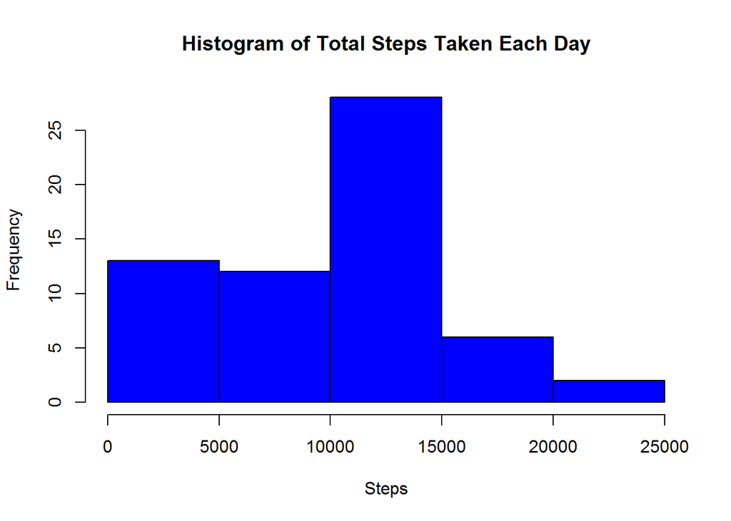

```r
#create histogram of number of steps taken each day
hist(x = dayTotal$steps, col="blue", main="Histogram of Total Steps Taken Each Day", xlab="Steps")
```

```r
#calculate and report the mean and median of the total number of steps taken per day, rounding down to nearest step
stepMean <- as.integer(mean(dayTotal$steps))
stepMedian <- as.integer(median(dayTotal$steps))
```

3. The mean total number of steps taken per day is 9354, and the median is 10395.

### What is the average daily activity pattern?

1. Time series plot of the 5-minute interval and the average number of steps taken, averaged across all days

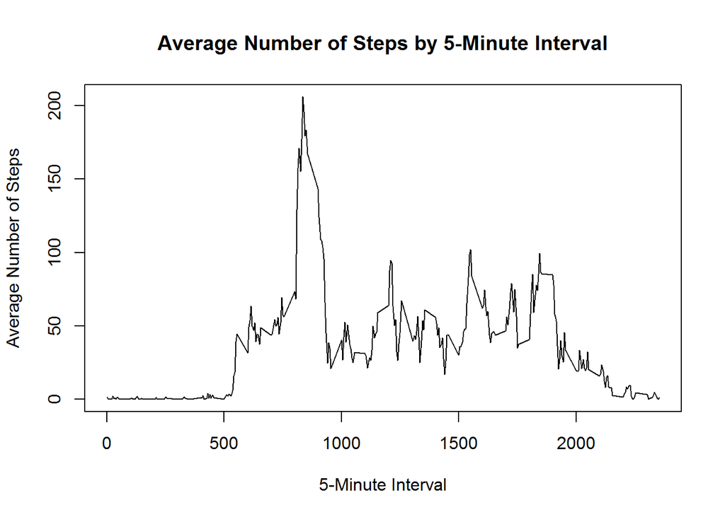

```r
data %>%
  select(-date) %>%
  group_by(interval) %>%
  summarize_each(funs(mean(., na.rm = TRUE))) -> min5mean

plot(x=min5mean$interval,y=min5mean$steps, type="l",main="Average Number of Steps by 5-Minute Interval", xlab="5-Minute Interval",ylab="Average Number of Steps")
```

2. Which 5-minute interval, on average across all the days in the dataset, contains the maximum number of steps?

```r
maxInterval <- filter(min5mean, steps == max(steps))[['interval']]
```

The 5-minute interval 835, contains the maximum number of steps averaged across all the days in dataset.

### Imputing missing values

1. Calculate and report the total number of missing values in the dataset

```r
numOfNa <- sum(is.na(data$steps))
```

The total number of missing values in the dataset is 2304

2. Choosing to take the mean of 5-min interval across all days for filling in all missing values in the dataset. I am using this because more likey to have same activity at same time of each day as opposed to average activity of entire day.
3. Create a new dataset that is equal to the original dataset but with the missing data filled in

```r
newData <- merge(data,min5mean,by='interval')
newData$steps <- newData$steps.x
newData$steps[is.na(newData$steps.x)] <- newData$steps.y[is.na(newData$steps.x)]
newData <- select(newData,interval,date,steps)
```

4. Histogram of the total number of steps taken each day, and calculate the mean and median total number of steps taken per day.

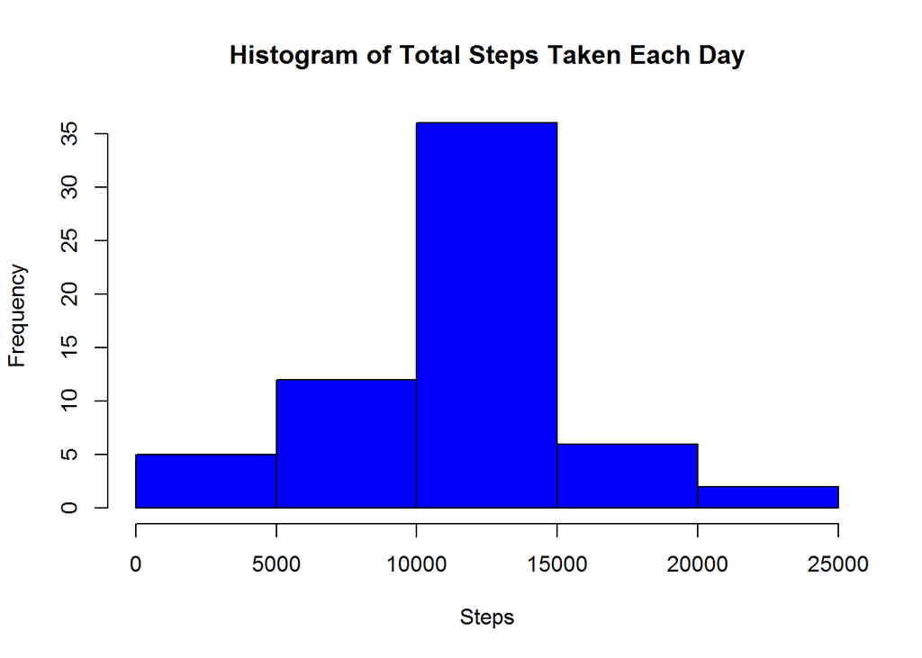

```r
newData %>%
  select(-interval) %>%
  group_by(date) %>%
  summarize_each(funs(sum(., na.rm = TRUE))) -> newDayTotal
hist(x = newDayTotal$steps, col="blue", main="Histogram of Total Steps Taken Each Day", xlab="Steps")
```

```r
newstepMean <- as.integer(mean(newDayTotal$steps))
newstepMedian <- as.integer(median(newDayTotal$steps))
```

The mean of 10766 and median 10766 do differ from estimates without filling in the missing data points. The impact of imputing missing data is both the mean and the median have increased. Also, the mean and median are now equal.

### Are there differences in activity patterns between weekdays and weekends?

1. Create a new factor variable in the dataset with two levels - “weekday” and “weekend” indicating whether a given date is a weekday or weekend day

```r
newData['date'] <- as.Date(newData$date)
newData['dayOfWeek'] <- weekdays(newData$date)
newData$dayType[newData$dayOfWeek %in% c('Saturday','Sunday')] <- 'weekend'
newData$dayType[!newData$dayOfWeek %in% c('Saturday','Sunday')] <- 'weekday'
newData$dayType <- as.factor(newData$dayType)
```

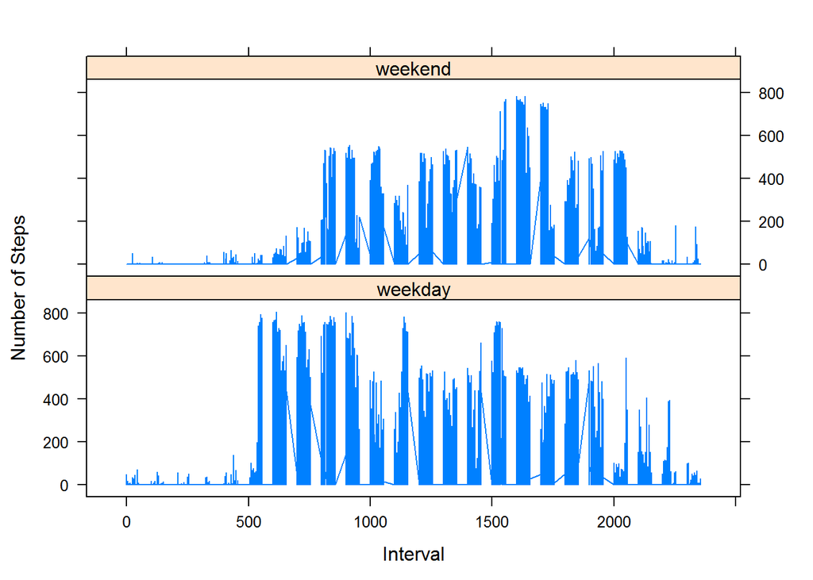

```r
xyplot(newData$steps~newData$interval|newData$dayType,type="l",layout=c(1,2),xlab="Interval",ylab="Number of Steps")
```